# Lab_6

## Lab 6

### Submitted By : Aagnay Kariyal

### Student ID : 8830232

```python
# Importing the dependencies
from sklearn.datasets import load_iris
from sklearn.linear_model import LogisticRegression
from sklearn.model_selection import train_test_split
from sklearn.metrics import accuracy_score, precision_score, confusion_matrix
import seaborn as sns
import numpy as np
import matplotlib.pyplot as plt

iris = load_iris(as_frame=True)
X = iris.data.values # Inserting all four features into a variable
```

```python
iris.target_names # Checking the target names
```

```
array(['setosa', 'versicolor', 'virginica'], dtype='<U10')
```

```python
y = iris.target_names[iris.target] == 'virginica' # Inserting the target variable, virginica
# Doing a train-test split on the model
X_train, X_test, y_train, y_test = train_test_split(X, y, test_size=0.2, random_state=0)
```

```python
model = LogisticRegression() # Running a logistic regression
model.fit(X_train, y_train) # Fitting the data in the logistic regression model
```

```
LogisticRegression()
```

```python
y_pred = model.predict(X_test) # Storing the predicted values into a variable
accuracy = accuracy_score(y_test, y_pred) # Getting the accuracy score
confusion_matrix = confusion_matrix(y_test, y_pred) # Getting the confusion matrix scores

print('The accuracy of the data is:', accuracy)
print(confusion_matrix)
```

```
The accuracy of the data is: 1.0
[[24  0]
 [ 0  6]]
```

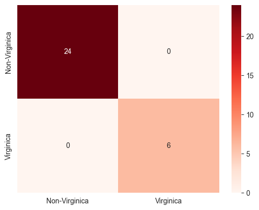

```python
# Defining labels for representation
labels = ["Non-Virginica", "Virginica"]

# Creating a heatmap for better understanding
sns.heatmap(confusion_matrix, annot=True, cmap="Reds",  xticklabels=labels, yticklabels=labels)
plt.show()
```

## 2. Evaluate the model:

The shared properties for these cases would be Precision and Recall.

#### iii. How is the model doing across a set of evaluation metrics: accuracy and confusion metric.

- As we can see from the above data, the accuracy of the data is 1. Which indicates extremely high accuracy, indicating that the data is absolutely accurate.
- From the confusion metric we can see that we only get True values i.e, True Positives and True Negatives.
- We got 24 True negative values, which indicated that the model predicted 24 values as Non-Virginica while they actually were Non-Virginica.
- We also got 6 values that were True Positives, which indicated that the model predicted 6 values as Virginica while they actually were Virginica.
- Here, Virginica is being represented as positives and Non-Virginica is being represented as negatives in the confusion matrix.